# A Brief Introduction to Bayesian Cognitive Modeling

4/18/2019

## Introduction & Background

## I’ll introduce Bayesian statistical modeling via an example

- Today I’ll discuss a **hierachical (multi-level) Bayesian model**
- This model will analyze data from Dr. Jiang’s Plasticity Lab
- The data arise from experiments studying *Temporal Recalibration*.

## Scientific background

- Our temporal perception can be modified by contextual factors (ex. adapting to some temporal delay in the environment) and by biological factors (ex. aging).
- With varying levels of temporal perception, it is difficult to determine which aspects are altered by aging.

## Main research questions (spoiler: we won’t answer these today)

- How does aging affect different types of temporal judgments?
- How does threshold (temporal sensitivity) change as a function of age?
- How does age affect temporal recalibration?

## Experimental design

- 4 tasks were given to subjects. But today we highlight the Audio-Visual (AV) task.
- The AV task presents two stimuli — an audio cue and a visual cue.
- The task for the subject is to determine which came first.
- Subjects were tested on a range of temporal delays that separated two stimuli. These are referred to as stimulus onset asynchronies (SOAs).

## AV task explained

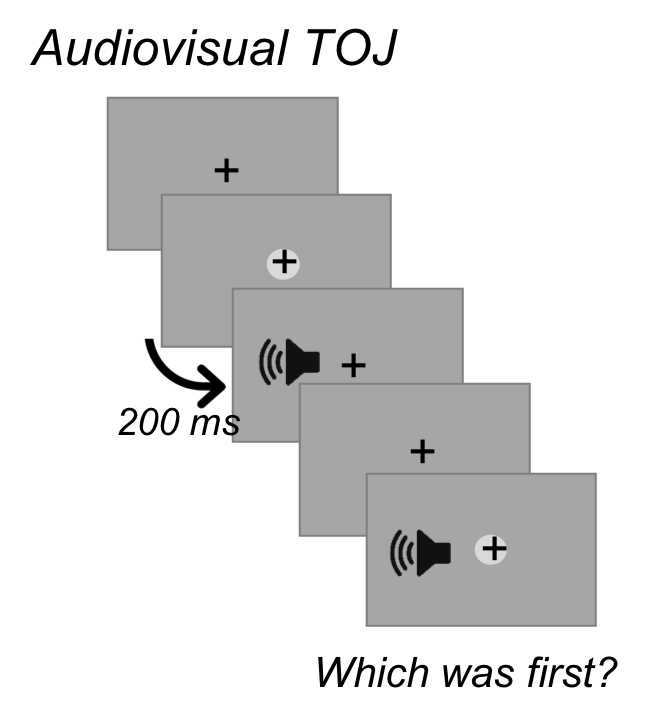

SOAs: -500 to +500 ms with 50 ms steps

## Subjects

- Young age group, n = 14, 18 – 30 years old
- Middle age group, n = 15, 40 – 50 years old
- Older age group, n = 15, 65 – 75 years old

## Exploration data analysis

## 10 responses for two individuals

Raw data: Male subject

| Separation (ms) | Response |
| --- | --- |
| -50 | 0 |
| -100 | 0 |
| -400 | 0 |
| 50 | 0 |
| 350 | 1 |
| -250 | 0 |
| 200 | 1 |
| 150 | 1 |
| 300 | 1 |
| -500 | 0 |

Raw data: Female subject

| Separation (ms) | Response |
| --- | --- |
| 0 | 1 |
| 150 | 1 |
| 0 | 1 |
| 250 | 1 |
| 50 | 1 |
| -200 | 0 |
| 400 | 1 |
| -400 | 0 |
| -250 | 0 |
| 250 | 1 |

## Tabulated data for a male subject

|  | Audio first | Visual First |
| --- | --- | --- |
| -500 | 5 | 0 |
| -450 | 4 | 1 |
| -400 | 5 | 0 |
| -350 | 5 | 0 |
| -300 | 5 | 0 |
| -250 | 5 | 0 |
| -200 | 5 | 0 |
| -150 | 5 | 0 |
| -100 | 5 | 0 |
| -50 | 5 | 0 |
| 0 | 5 | 0 |
| 50 | 3 | 2 |
| 100 | 4 | 1 |
| 150 | 2 | 3 |
| 200 | 1 | 4 |
| 250 | 0 | 5 |
| 300 | 0 | 5 |
| 350 | 0 | 5 |
| 400 | 0 | 5 |
| 450 | 0 | 5 |
| 500 | 0 | 5 |

## Tabulated data for a female subject

|  | Audio first | Visual First |
| --- | --- | --- |
| -500 | 5 | 0 |
| -450 | 5 | 0 |
| -400 | 5 | 0 |
| -350 | 5 | 0 |
| -300 | 5 | 0 |
| -250 | 4 | 1 |
| -200 | 4 | 1 |
| -150 | 2 | 3 |
| -100 | 3 | 2 |
| -50 | 0 | 5 |
| 0 | 0 | 5 |
| 50 | 0 | 5 |
| 100 | 0 | 5 |
| 150 | 0 | 5 |
| 200 | 0 | 5 |
| 250 | 0 | 5 |
| 300 | 0 | 5 |
| 350 | 0 | 5 |
| 400 | 0 | 5 |
| 450 | 0 | 5 |
| 500 | 0 | 5 |

## Proportions for the male subject

| Separation (ms) | Proportion |
| --- | --- |
| -450 | 0.2 |
| -400 | 0.0 |
| -250 | 0.0 |
| -200 | 0.0 |
| -150 | 0.0 |
| 0 | 0.0 |
| 100 | 0.2 |
| 250 | 1.0 |
| 300 | 1.0 |
| 450 | 1.0 |

## Proportions for the female subject

| Separation (ms) | Proportion |
| --- | --- |
| -350 | 0.0 |
| -300 | 0.0 |
| -250 | 0.2 |
| -150 | 0.6 |
| -100 | 0.4 |
| 0 | 1.0 |
| 100 | 1.0 |
| 150 | 1.0 |
| 350 | 1.0 |
| 400 | 1.0 |

## Scatterplot of the male subject

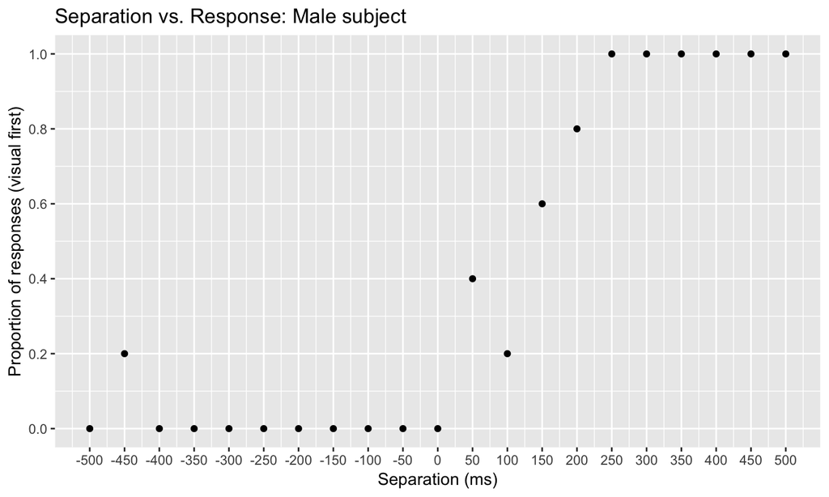

## Scatterplot of the female subject

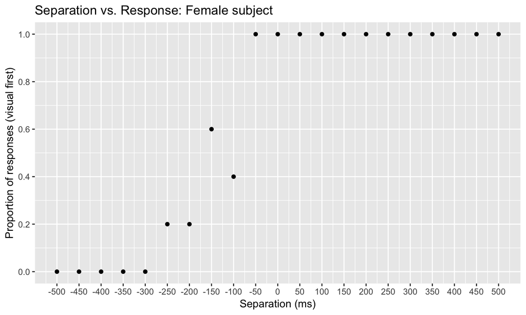

## Statistical modeling

## It’s possible to fit an “S-shaped” curve

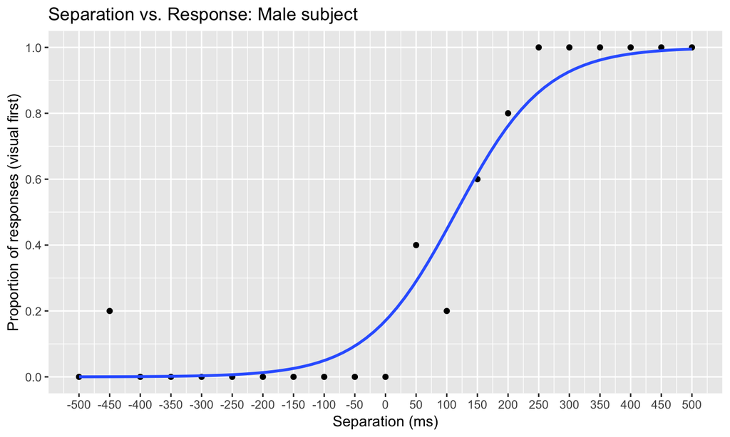

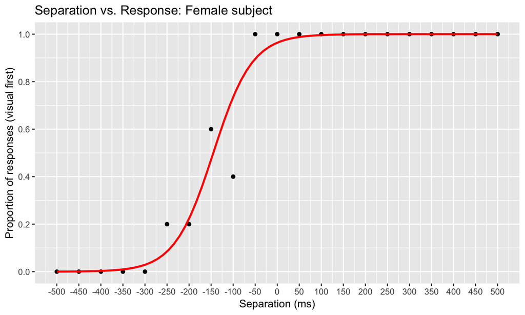

## Bayesian Statistics 101

- Bayesian statistics is a mathematical formalization of learning from data.
- We use variables (called *parameters*) to model quantities of interest.
- These parameters are **unobservable** and we are *uncertain** of their values.
- So we treat them as *random variables* and give probaibilities to their values.

## Bayesian Statistics 101

- Bayes’ rule combines our prior knowledge of the parameters with the data at hand.
- The result is a new probability distribution, called the *posterior* that reflects our updated beliefs.
- Bayes’ rule can be summarized as

\(posterior \propto (prior) \times (likelihood)\).

## A graphical hierachical model

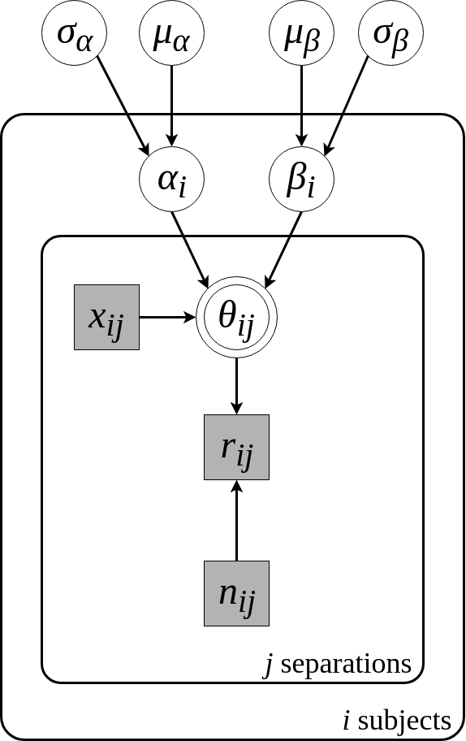

## Probability distributions on data and parameters

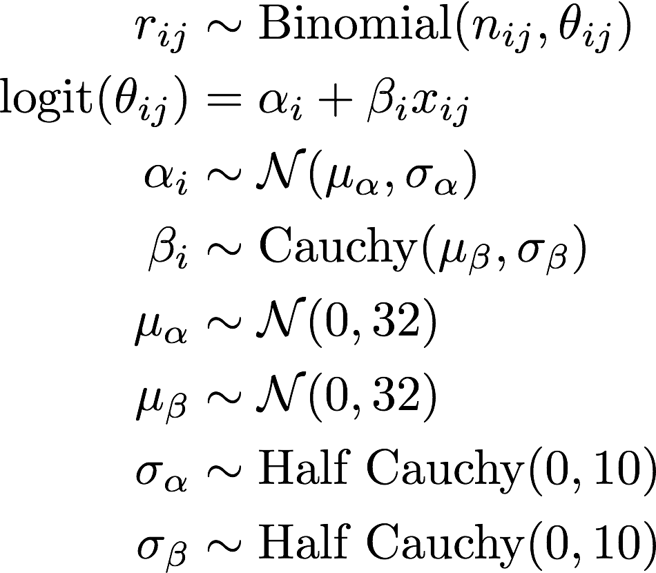

## Results: Uncertanity quantification

## Samples of curves from the posterior

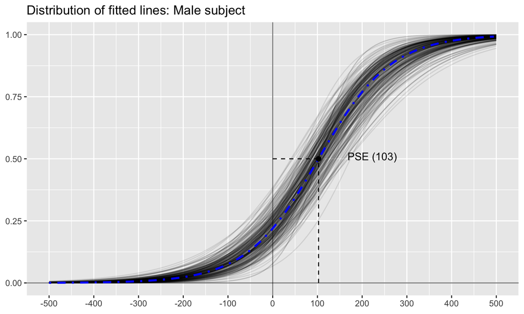

## Samples of curves from the posterior

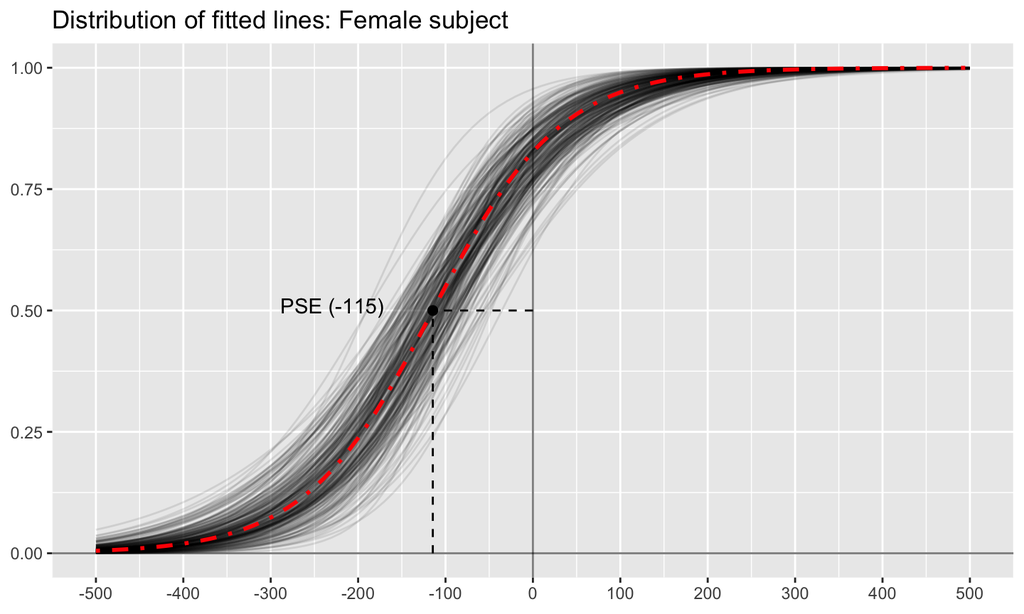

## Using the hierarchy: group inferences

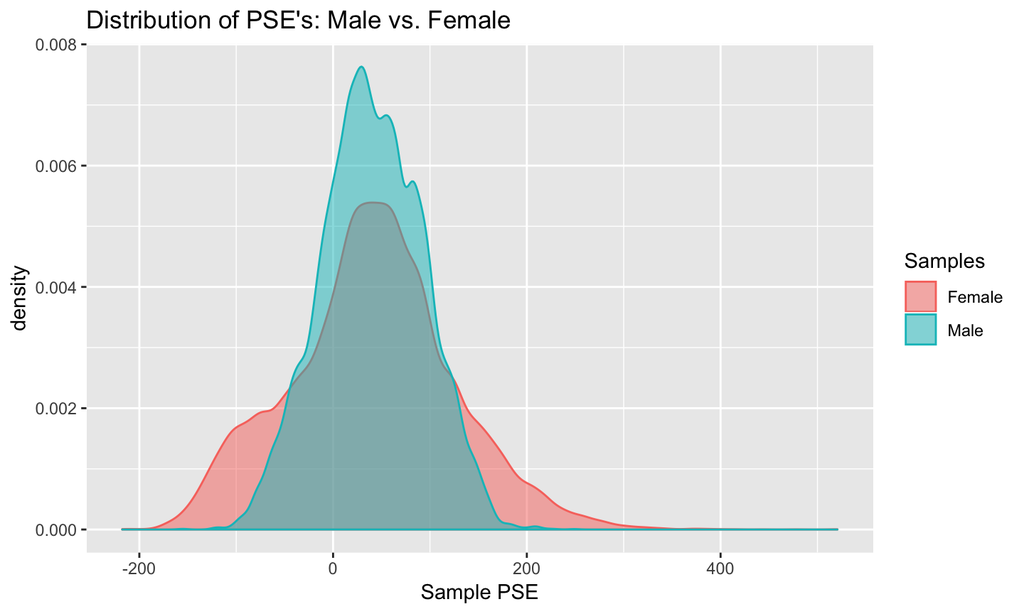

## Concluding remarks

## Next steps for this project

- Evaluate and refine the model to include adapatation, age, etc.
- Test various hypotheses using the final model
- Communicate the results

## How can you learn more?

- Consider a stats minor.
- Take an Introduction to Bayesian Statistics (STAT 446) offered in Spring semesters.
- Conduct undergraduate research.
- Check out my website: [www.grantschissler.com](http://www.grantschissler.com/)

## Thank you for your attention

[figure not shown]